# Just how bad is my luck while observing?

After spending the last two nights watching clouds at McDonald Observatory, I started to wonder just how bad my luck really is, compared to other observers here. It hit me that there may be a way to quantify it, using the nightly report system. Every night, observers have to fill out a log that looks like this:

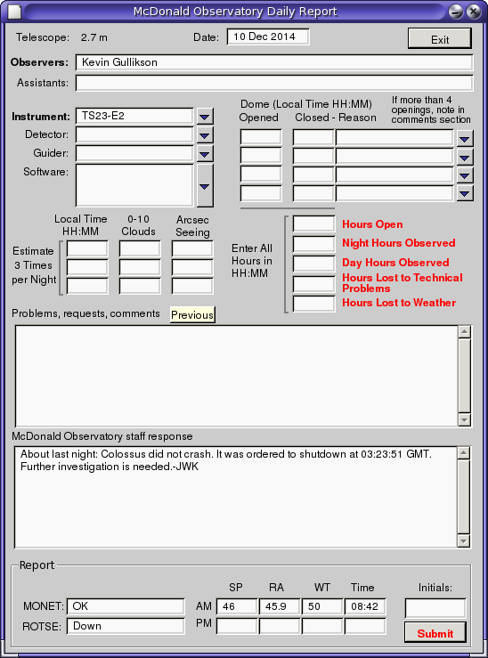

```python
from IPython.display import Image
Image(filename='/home/kgullikson/Dropbox/Ipython_Notebooks/Figures/night_report.png')
```

The idea here is to go through the night report archive, and pull data about how much time was lost to weather for each observer. There are several problems with this approach, some of which I attempt to fix below, but a big one is that it is entirely self-reported. Nonetheless, we move along... I downloaded all of the night reports from the 2.1 and 2.7 meter telescopes from 2010 to now and got to parsing.

As you can see, the night report has fields for the number of hours open, the number of hours observed, and the number of hours lost throughout the night. While the most useful field may be the number of hours lost, that one was not required until recently and so most people didn't fill it out. Thankfully, the number of hours observed has been required at least as long as I have been here. So my approach will be to subtract the length of the night, which I used the handy [pyEphem](https://pypi.python.org/pypi/ephem/) package to calculate, from the number of hours observed to get the number of hours that it was dark out but no observations were taking place.

## Difficulty 1: Standardizing the number of hours observed

That sounds all well and good, until you realize that people can put pretty much whatever they want in all of the fields. So, there are entries in the hours fields like: * 4.5 * 4:30 * 4,5 (some people use commas like decimal points, I think?) * 4.5h * 4h30m

There were also a few instances where people put text in there too (things like '4 (est.)'), and even some where they managed to leave it blank. For the latter, I just assumed 0 nights observed. For the rest of the cases, there is a pretty obvious way to convert to a decimal number of hours observed, and I just had to have a long chain of if-then-else commands to get it sorted out.

## Difficulty 2: Getting the observer names

Next, I had to associate the number of hours lost with a given observer. Again, that seems trivial but has lots of complications. First, people don't always enter their name in the same way. We get entries like: * Kevin Gullikson * K. Gullikson * KG

I can standardize the first two options by just using the last name, and crossing my fingers that we don't have too many observers with last names like 'Adams' or 'Smith'. Fortunately, that seems to be the case. The last example of just using initials is more difficult, since there is not an obvious way to uniquely associate a given set of initials with a last name. So, I just give up and treat initials as a separate observer, while the first two examples get put under the same observer. There are not very many instances of people just using initials, so I don't think it will affect the final stats much.

There is a second complication with observer names: more than one observer. There are lots of instances where either a couple observers are sharing a night, or a whole team of people are observing. This one is pretty easy to solve too: the different observers are split by one of the following words/characters: * and * & * /

So, I can just split up the observers by any of those characters (being careful that the word 'and' is its own word and not part of a name like Anderson).

Finally, some people again managed to leave the (required) Observer field blank. Since I have no way to assign an observer to that night report, I just leave it blank. I will have to remove the blank observers from the compiled lists before working out the final statistics. To try to make sure that I don't let a single bad (or good) run bias someone's results, I also cut out any observer with less than 20 total nights. The cutoff of 20 is pretty arbitrary, but seems reasonable to me and results in 62 distinct observers.

## Overall Statistics

We are going to look 2 different statistical measures of observing luck. First will be the total amount of time lost to weather or other effects, divided by the total amount of dark time the observer had. The average observer loses \(43 \pm 9\%\) of their time to bad luck. I think the absolute numbers might be biased a bit high, because I used sunset to sunrise as the amount of observable time. Most observers wait a little while after sunset to start observing, which will skew the time lost higher by up to an hour per night. More worrying for this comparative analysis, it could make observers who need darker conditions seem unlucky since they might wait longer and quit earlier. Still, 43% is crazy high!

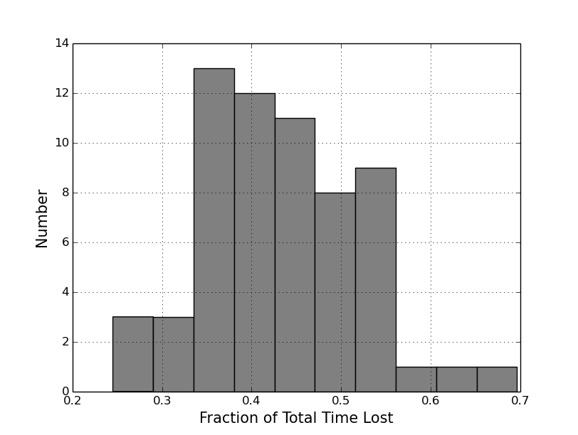

```python
Image(filename='/home/kgullikson/Dropbox/Ipython_Notebooks/Figures/TimeLost.png')
```

Next, we will compare the number of nights where over half of the night was lost to weather, normalized by the total number of nights. This should be similar to the the total fraction of time lost, but it will not be skewed by a relatively small number of very bad nights. Here, the average is \(34 \pm 11\%\). As it turns out, the best and worst observers are the same.

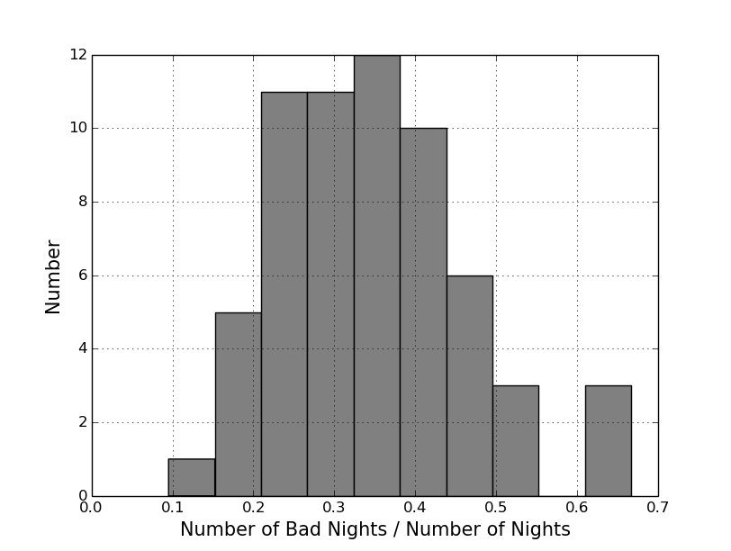

```python
Image(filename='/home/kgullikson/Dropbox/Ipython_Notebooks/Figures/NightsLost.png')
```

## So, just how bad am I, the notorious bringer of bad weather?

Surprisingly, I fall near the middle of the pack. I have had a total of 85 nights, 33 of which were very bad (I lost over 50% of the night). In total I have lost about 47% of my total night-time to bad weather. That puts me in the 70th percentile for total time lost, and the 67th percentile for the number of very bad nights. I am less lucky than the average observer, but nowhere near as unlucky as most people believe.